# Analysis

Chetna Jhurani

February 20, 2018

## A Simple Glance at the Data

Coverage Data

[output not shown]

Arranged Coverage Data

| X1 | Ingredient | Strength | Dosage | AMPs | Full | Paid | PPMG | Type | Pure |
| --- | --- | --- | --- | --- | --- | --- | --- | --- | --- |
| 4 | HYDROCHLOROTHIAZIDE | 25 | TABLET | 0.003227 | 0.009900 | 0.006673 | 0.0002669 | diuretic | Y |
| 9 | LOSARTAN POTASSIUM | 100 | TABLET | 0.038030 | 0.066553 | 0.028523 | 0.0002852 | ARB | N |
| 1 | ACEBUTOLOL HYDROCHLORIDE | 200 | CAPSULE | 0.134564 | 0.235487 | 0.100923 | 0.0005046 | beta blocker | N |
| 5 | LISINOPRIL | 40 | TABLET | 0.031287 | 0.054752 | 0.023465 | 0.0005866 | ACE inhibitor | Y |
| 2 | ATENOLOL | 100 | TABLET | 0.079799 | 0.139648 | 0.059849 | 0.0005985 | beta blocker | Y |
| 7 | BENAZEPRIL HYDROCHLORIDE | 40 | TABLET | 0.029580 | 0.059590 | 0.030010 | 0.0007503 | ACE inhibitor | N |
| 6 | DILTIAZEM HYDROCHLORIDE | 360 | CAPSULE, EXTENDED RELEASE | 0.333229 | 0.616180 | 0.282951 | 0.0007860 | CCB | N |
| 8 | AMLODIPINE BESYLATE | 10 | TABLET | 0.019519 | 0.034158 | 0.014639 | 0.0014639 | CCB | N |
| 3 | CAPTOPRIL | 100 | TABLET | 0.580250 | 1.777050 | 1.196800 | 0.0119680 | ACE inhibitor | Y |
| 10 | CANDESARTAN CILEXETIL | 32 | TABLET | 1.190418 | 2.083232 | 0.892814 | 0.0279004 | ARB | N |

Looking at the data here, there do seem to be some trends in the prices such as the type of drug as well as the purity of the substances. However, this will probably be much more visible in scatter plots.

## Scatterplot

Below is a basic scatterplot of all of the hypertension medications. However, this plot by itself doesn’t really reveal much.

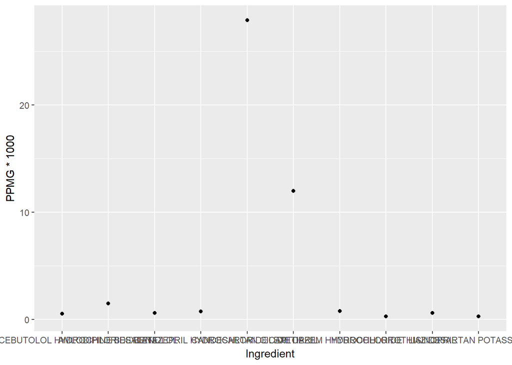

## Taking it a Step Further

To test out the theory that there is a noticable difference in price based on purity and the method of action for each drug, some sort of summary statistic is needed. I chose to use the mean, since there is little data based on type.

```r
cov_type <- coverage_clean %>%
  group_by(Type) %>%
  summarize(mean_PPMG = mean(PPMG)) %>%
  arrange(mean_PPMG)

cov_pure <- coverage_clean %>%
  group_by(Pure) %>%
  summarize(mean_PPMG = mean(PPMG)) %>%
  arrange (mean_PPMG)
```

Now that the statistics have been saved, they can be graphed. I chose to use a scatterplot for both statistics.

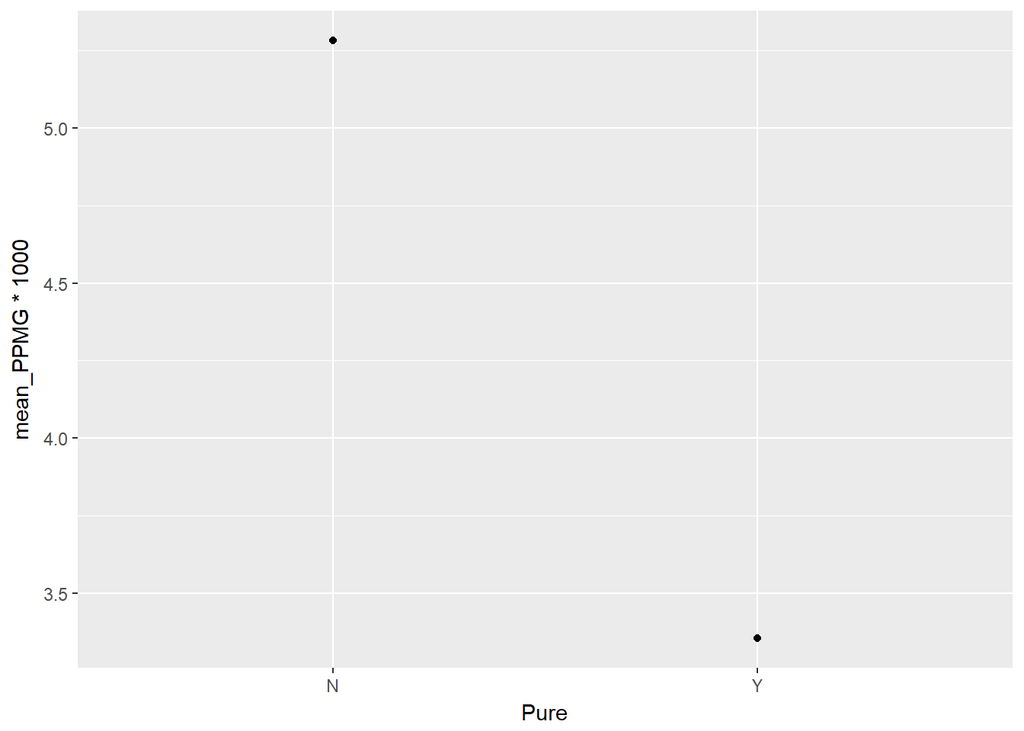

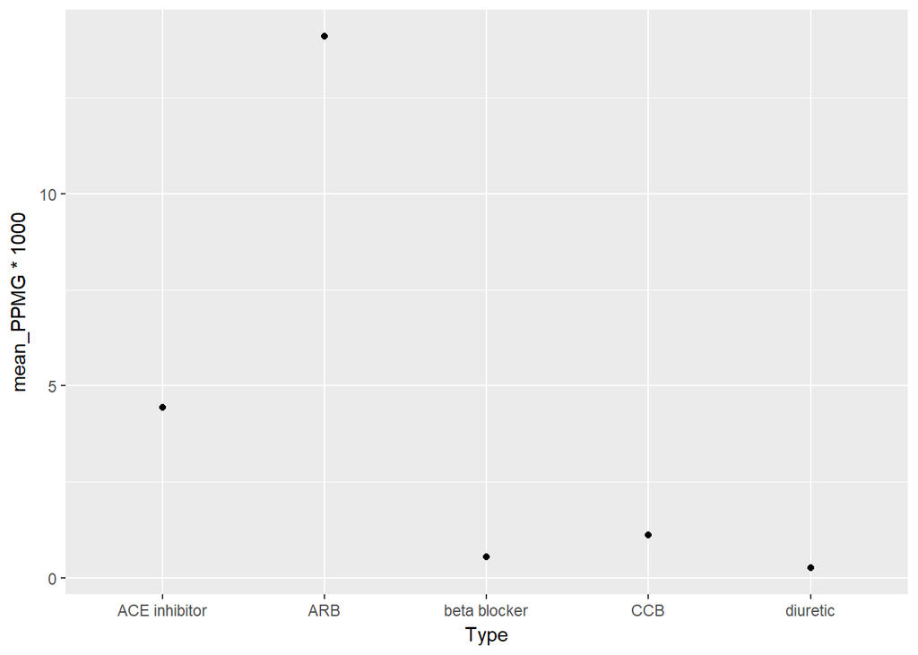

Looking at these graphs, the theory is confirmed. There is a noticable difference in both the type of hypertension medication prescribed and its purity. Looking first at the purity, there is an obvious price increase when the medication is not a pure substance. This make sense, as it involves including more than one substance.

## Why Only Scatterplots

Only scatterplots are included here in order to note the trends as most of this data is qualitative. There is no measure of frequency, so there is no need for a bar graph, histogram, or box and whisker plot. Additionally, as the independent variable is qualitative, a line graph also has no purpose as all the levels on the x-axis are equal.